# Model Selection Tutortial - Patterson

Samuel Patterson

February 19, 2019

```r
knitr::opts_chunk$set(echo = TRUE)
```

Lets load the pack **tidyverse** data manipulation/visulation **leaps** model selection fucntions

```r
library(tidyverse)
library(leaps)
library(ISLR)
library(glmnet)
```

Load the data…

We will be working with a data set called **Hitters**, a data set contains the batting averages and variables assocaited with hitting at bat

```r
(
  hitters <- na.omit(ISLR::Hitters) %>%
    as_tibble
  )
```

```
## # A tibble: 263 x 20
##    AtBat  Hits HmRun  Runs   RBI Walks Years CAtBat CHits CHmRun CRuns
##  * <int> <int> <int> <int> <int> <int> <int>  <int> <int>  <int> <int>
##  1   315    81     7    24    38    39    14   3449   835     69   321
##  2   479   130    18    66    72    76     3   1624   457     63   224
##  3   496   141    20    65    78    37    11   5628  1575    225   828
##  4   321    87    10    39    42    30     2    396   101     12    48
##  5   594   169     4    74    51    35    11   4408  1133     19   501
##  6   185    37     1    23     8    21     2    214    42      1    30
##  7   298    73     0    24    24     7     3    509   108      0    41
##  8   323    81     6    26    32     8     2    341    86      6    32
##  9   401    92    17    49    66    65    13   5206  1332    253   784
## 10   574   159    21   107    75    59    10   4631  1300     90   702
## # ... with 253 more rows, and 9 more variables: CRBI <int>, CWalks <int>,
## #   League <fct>, Division <fct>, PutOuts <int>, Assists <int>,
## #   Errors <int>, Salary <dbl>, NewLeague <fct>
```

# Best Subset Selection

- Fit least squares regression for each possible combination of the p predictors
- Fit all p models to have exatcly one p or predictor, exatcly 2 p or predictors and so on….
- Then use repo to identify best model and fit
- 3 stage process - best subset selction includes:
1. Let M0 denote the null model - no predictor variables. Only sample mean for each observation.
2. For K=1,2,3….p
- Fit all (p/k) models that contain exatcly k predictors
- pick the best among the models, and dub this model Mk - best being defined as the smallest RSS or largest R2
3. Select a single best model from among the null and Mp models using the cross-validated error, Cp, AIC, BIC or adjusted R2
- Preform best subset search using the regsubsets (part of the leaps library)
- This will identify the best model for a given number of k predictors where best is quantified using RSS
- The syntax is the same as the lm fucntion
- By deafult regsubsets only reports results up to the best eight variable model
- nvmax option can be paired to return as many variables as desired
- we will fit 19 variables to this model for example

```r
best_subset <- regsubsets(Salary ~ ., hitters, nvmax=19)
```

The ‘subsets’ function returns a list-object. Initaly we can use ‘summary’ to view and assess all of the models selected for each p size.  
* The best 1 variable model is ‘salary ~ CRBI’, the best 2 variable model is ‘Salary ~ CRBI + Hits’, best 3 variable model ’Salary ~ CRBI + Hits + PutOuts.

```r
summary(best_subset)
```

```
## Subset selection object
## Call: regsubsets.formula(Salary ~ ., hitters, nvmax = 19)
## 19 Variables  (and intercept)
##            Forced in Forced out
## AtBat          FALSE      FALSE
## Hits           FALSE      FALSE
## HmRun          FALSE      FALSE
## Runs           FALSE      FALSE
## RBI            FALSE      FALSE
## Walks          FALSE      FALSE
## Years          FALSE      FALSE
## CAtBat         FALSE      FALSE
## CHits          FALSE      FALSE
## CHmRun         FALSE      FALSE
## CRuns          FALSE      FALSE
## CRBI           FALSE      FALSE
## CWalks         FALSE      FALSE
## LeagueN        FALSE      FALSE
## DivisionW      FALSE      FALSE
## PutOuts        FALSE      FALSE
## Assists        FALSE      FALSE
## Errors         FALSE      FALSE
## NewLeagueN     FALSE      FALSE
## 1 subsets of each size up to 19
## Selection Algorithm: exhaustive
##           AtBat Hits HmRun Runs RBI Walks Years CAtBat CHits CHmRun CRuns
## 1  ( 1 )  " "   " "  " "   " "  " " " "   " "   " "    " "   " "    " "
## 2  ( 1 )  " "   "*"  " "   " "  " " " "   " "   " "    " "   " "    " "
## 3  ( 1 )  " "   "*"  " "   " "  " " " "   " "   " "    " "   " "    " "
## 4  ( 1 )  " "   "*"  " "   " "  " " " "   " "   " "    " "   " "    " "
## 5  ( 1 )  "*"   "*"  " "   " "  " " " "   " "   " "    " "   " "    " "
## 6  ( 1 )  "*"   "*"  " "   " "  " " "*"   " "   " "    " "   " "    " "
## 7  ( 1 )  " "   "*"  " "   " "  " " "*"   " "   "*"    "*"   "*"    " "
## 8  ( 1 )  "*"   "*"  " "   " "  " " "*"   " "   " "    " "   "*"    "*"
## 9  ( 1 )  "*"   "*"  " "   " "  " " "*"   " "   "*"    " "   " "    "*"
## 10  ( 1 ) "*"   "*"  " "   " "  " " "*"   " "   "*"    " "   " "    "*"
## 11  ( 1 ) "*"   "*"  " "   " "  " " "*"   " "   "*"    " "   " "    "*"
## 12  ( 1 ) "*"   "*"  " "   "*"  " " "*"   " "   "*"    " "   " "    "*"
## 13  ( 1 ) "*"   "*"  " "   "*"  " " "*"   " "   "*"    " "   " "    "*"
## 14  ( 1 ) "*"   "*"  "*"   "*"  " " "*"   " "   "*"    " "   " "    "*"
```

[output cut: 10 more lines]

```
## 5  ( 1 )  "*"  " "    " "     "*"       "*"     " "     " "    " "
## 6  ( 1 )  "*"  " "    " "     "*"       "*"     " "     " "    " "
## 7  ( 1 )  " "  " "    " "     "*"       "*"     " "     " "    " "
## 8  ( 1 )  " "  "*"    " "     "*"       "*"     " "     " "    " "
## 9  ( 1 )  "*"  "*"    " "     "*"       "*"     " "     " "    " "
## 10  ( 1 ) "*"  "*"    " "     "*"       "*"     "*"     " "    " "
## 11  ( 1 ) "*"  "*"    "*"     "*"       "*"     "*"     " "    " "
## 12  ( 1 ) "*"  "*"    "*"     "*"       "*"     "*"     " "    " "
## 13  ( 1 ) "*"  "*"    "*"     "*"       "*"     "*"     "*"    " "
## 14  ( 1 ) "*"  "*"    "*"     "*"       "*"     "*"     "*"    " "
## 15  ( 1 ) "*"  "*"    "*"     "*"       "*"     "*"     "*"    " "
## 16  ( 1 ) "*"  "*"    "*"     "*"       "*"     "*"     "*"    " "
## 17  ( 1 ) "*"  "*"    "*"     "*"       "*"     "*"     "*"    "*"
## 18  ( 1 ) "*"  "*"    "*"     "*"       "*"     "*"     "*"    "*"
## 19  ( 1 ) "*"  "*"    "*"     "*"       "*"     "*"     "*"    "*"
```

# Stepwise selection - Drawbacks of best Subset

- Best subset method suffers from statistical problems when p is to large
- the more variables increases the chane of having a model preform to well on trainning data - while having low predictive effect on future data
- thus many variables can lead to overfitting
- stepwise is an attractive alternative as you can control the number of models generated more easily #Forward Stepwise
- the null model again contains no predictors and adds predictor terms one step at a time
- each addition of a predictor that adds additonal improvment to the model is fitted in a stepwise manner
- 3 Steps
1. Let M0 denote the null model, which contains no predictors. this model simply predicts the sample mean for each observation.
2. For k = 0,…, p-1
- Consider all p - k models that augment the preditors in Mk with one additional predictor
- Choose the best among these p-k models, and call it Mk+1 +here the best fit is defined as having the smallest RSS or highest R2
3. Select the single best model from among M0,….,Mp using cross-validated predicition error, Cp,AIC,BIC or Adjusted R2

**Preform forward slection using ‘regsubsets’ by inclduing the term ‘method=“forward”’

```r
forward <- regsubsets(Salary ~ ., hitters, nvmax = 19, method = "forward")
```

# Backward selection

- The same basic function as forward selection
- Main Diff: For K = p,p-1,…,1
- All k models that contain all but one of the predictors in Mk for a total of K-1 predictors
- Choose the best among the k models, and call it Mk-1
- Again using ‘regsubsets’, with ‘method = “backwards”’

```r
backward <- regsubsets(Salary ~ ., hitters, nvmax = 19, method = "backward")
```

# Comparing Models

- First we need to indetify the test error associated with each model
1. Indirectly estimate the test error by making an adjustment to the trainning error to account for the bias due to overfitting
2. We can directly estimate the test error using either a validation set approach or a cross-validation approach

** R2 and MSE should not be used for model selection as the results of these test statistics is proportional to the numbe rof preodctors and is not accurate to the fit of the model in this case**

**Cp, AIC, BIC and adjusted R2 values all are corrected for model selection as they add a penatly to the models that add extra predictors**  
**Models with a higher number of preidctors will be peanlized to a greater degree than those with fewer**

# Output of Regsubsets

- All of theese indicator values are storred in the fucntion regsubsets
- To extract this information and plot them…

```r
#creating training data for model
set.seed(1)
sample <- sample(c(TRUE, FALSE), nrow(hitters), replace = T, prob = c(0.6,0.4))
train <- hitters[sample, ]
test <- hitters[!sample, ]
```

```r
#Preform best subset selection
best_subset <- regsubsets(Salary ~ ., train, nvmax = 19)
results <- summary(best_subset)
```

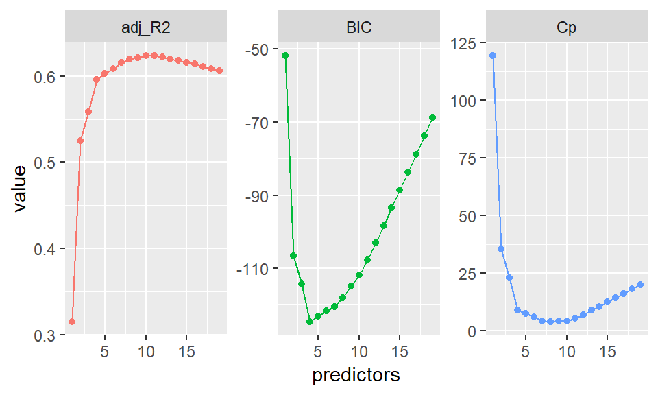

```r
#Extract and Plot Results
tibble(predictors = 1:19,
       adj_R2 = results$adjr2,
       Cp = results$cp,
       BIC = results$bic) %>%
  gather(statistic, value, -predictors) %>%
  ggplot(aes(predictors, value, color = statistic)) +
  geom_line(show.legend = F) +
  geom_point(show.legend = F) +
  facet_wrap(~ statistic, scales = "free")
```

**Notice that the adj. R2 value is a maximum error method while AIC, BIC and Cp are minimal error methods**

```r
which.max(results$adjr2)
```

```
## [1] 10
```

```r
which.min(results$bic)
```

```
## [1] 4
```

```r
which.min(results$cp)
```

```
## [1] 8
```

**All of theese indicator values suggest a diffrent model to be selected. The R2 suggests 10 variable model, the BIC statsitic suggests the 4 variable and the Cp value suggest the 8 variable model**

- can compare the variables and coeffecients that theese models include using the coef function

```r
coef(best_subset, 10)
```

```
## (Intercept)       AtBat        Hits       Walks      CAtBat       CHits
## -47.3715661  -1.3695666   6.3013473   4.5757613  -0.3118794   1.4799307
##      CHmRun      CWalks     LeagueN   DivisionW     PutOuts
##   1.2971405  -0.5026157  62.5613310 -62.3548737   0.2527181
```

```r
coef(best_subset, 4)
```

```
## (Intercept)        Runs      CAtBat       CHits     PutOuts
## -83.1199265   5.5530883  -0.4741822   2.0560595   0.3118252
```

```r
coef(best_subset, 8)
```

```
## (Intercept)       AtBat        Hits       Walks      CAtBat       CHits
## -59.2371674  -1.4744877   6.6802515   4.4777879  -0.3203862   1.5160882
##      CHmRun      CWalks     PutOuts
##   1.1861142  -0.4714870   0.2748103
```

# Preform forward & backward slection again and compare terms

```r
forward <- regsubsets(Salary ~ ., train, nvmax = 19, method = "forward")
backward <- regsubsets(Salary ~ ., train, nvmax = 19, method = "backward")
```

```r
# which models minimize Cp?
which.min(summary(forward)$cp)
```

```
## [1] 8
```

```r
## [1] 8
which.min(summary(backward)$cp)
```

```
## [1] 8
```

```r
## [1] 8
```

**Notice that both the forward and backward method both produced models with 8 variables - lets inspect the components that each method selected**

```r
coef(best_subset, 8)
```

```
## (Intercept)       AtBat        Hits       Walks      CAtBat       CHits
## -59.2371674  -1.4744877   6.6802515   4.4777879  -0.3203862   1.5160882
##      CHmRun      CWalks     PutOuts
##   1.1861142  -0.4714870   0.2748103
```

```r
coef(forward, 8)
```

```
##  (Intercept)        AtBat         Hits        Walks        CRuns
## -112.7724200   -2.1421859    8.8914064    5.4283843    0.8555089
##         CRBI       CWalks      LeagueN      PutOuts
##    0.4866528   -0.9672115   64.1628445    0.2767328
```

```r
coef(backward, 8)
```

```
## (Intercept)       AtBat        Hits       Walks      CAtBat       CHits
## -59.2371674  -1.4744877   6.6802515   4.4777879  -0.3203862   1.5160882
##      CHmRun      CWalks     PutOuts
##   1.1861142  -0.4714870   0.2748103
```

This highlights the diffrences between the two forward and backward selection methods…

1. Different subsetting procedures (best subset vs. forward stepwise vs. backward stepwise) will likely identify different “best” models
2. Different indrect error test esitamte statistics (Cp, AIC, BIC, and Adj, R2) will likely identify the “best model”
3. For biological variables in particular it is important to consider the ecological/biolgoical components of youyr models and although a predictor may be non-signficant - if you belive it is important than it should be included

# Directly Estimating Error

```r
test_model<-model.matrix(Salary ~., data = test)
```

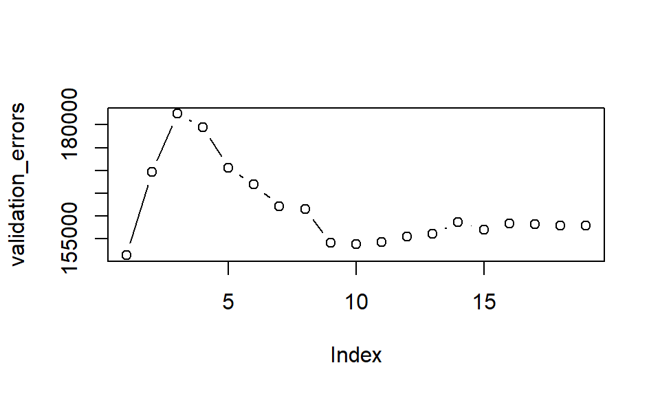

```r
#Create an empty vector to fill with error values
validation_errors<-vector("double",length = 19)

for (i in 1:19) {
  coef_x<-coef(best_subset,id=i)  #extract coeffcients for model size i
  pred_x<-test_model[ , names(coef_x)]%*% coef_x #predict salary using matrix algebra
  validation_errors[i] <- mean ((test$Salary - pred_x)^2) #compute test error between actual and predicted salarys
}
#plot validation errors
plot(validation_errors, type="b")
```

- *This method indicates that the one variable model actually has the lowest MSE
- However, if you repeat this proccess with a diffrent ‘random value seed’ we will generate a slightly different best model

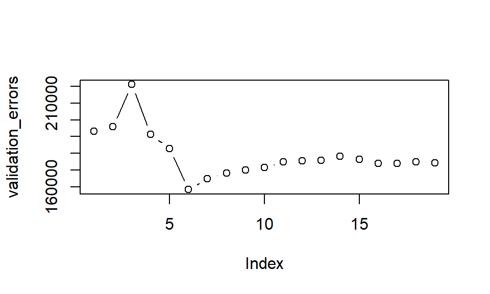

```r
# create training - testing data
set.seed(5)
sample <- sample(c(TRUE, FALSE), nrow(hitters), replace = T, prob = c(0.6,0.4))
train <- hitters[sample, ]
test <- hitters[!sample, ]

# perform best subset selection
best_subset <- regsubsets(Salary ~ ., train, nvmax = 19)

# compute test validation errors
test_model <- model.matrix(Salary ~ ., data = test)
validation_errors <- vector("double", length = 19)

for(i in 1:19) {
  coef_x <- coef(best_subset, id = i)                     # extract coefficients for model size i
  pred_x <- test_model[ , names(coef_x)] %*% coef_x           # predict salary using matrix algebra
  validation_errors[i] <- mean((test$Salary - pred_x)^2)  # compute test error btwn actual & predicted salary
}

# plot validation errors
plot(validation_errors, type = "b")
```

**Create a function using the steps above to simplify the proccess**

```r
predict.regsubsets <- function(object, newdata, id ,...) {
  form <- as.formula(object$call[[2]])
  mat <- model.matrix(form, newdata)
  coefi <- coef(object, id = id)
  xvars <- names(coefi)
  mat[, xvars] %*% coefi
  }
```

- Now this function can help choose from the models of differing size using the K-fold cross-validation approach
- The best subset selection within each of the k training sets is prefomred here
- First create a vector that allocates each observation to one of k = 10 folds, and we create a matrix in which we will stroe the results

```r
k <- 10
set.seed(1)
folds <- sample(1:k, nrow(hitters), replace = TRUE)
cv_errors <- matrix(NA, k, 19, dimnames = list(NULL, paste(1:19)))
```

- Now, create a loop for cross validation of model selection
- *In the jth fold, the elements of folds that equal j are in the test set and the remainder are in the trainning set*
- Essentialy predictions are made for each model size, the test errors on the approate subsets are computed, and the results are stored in a matrix ‘cv_errors’

```r
for(j in 1:k) {

  # perform best subset on rows not equal to j
  best_subset <- regsubsets(Salary ~ ., hitters[folds != j, ], nvmax = 19)

  # perform cross-validation
  for( i in 1:19) {
    pred_x <- predict.regsubsets(best_subset, hitters[folds == j, ], id = i)
    cv_errors[j, i] <- mean((hitters$Salary[folds == j] - pred_x)^2)
    }
  }
```

- The result is a 10x19 matrix of which he (i,j)th element corresponds to the test MSE for the ith cross-validation fold for the best j-variable model
- Use the `colmeans` function to average over the coloumns of the matrix
- This result is the cross-validation error for the j-variable model

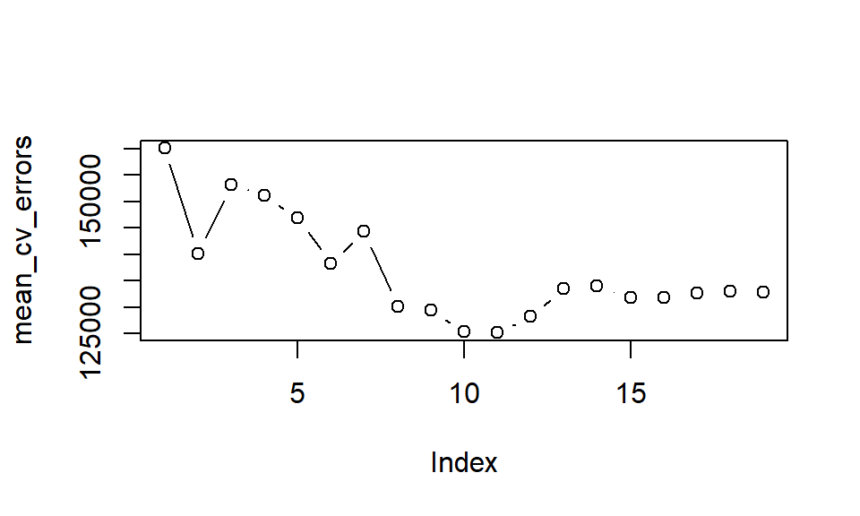

```r
mean_cv_errors <- colMeans(cv_errors)

plot(mean_cv_errors, type = "b")
```

* From this we see that the cross validated approach slects an 11 variable model * knowning this we can preform a subset slection for 11 variables on the orginal data set

```r
final_best <- regsubsets(Salary ~ ., data = hitters , nvmax = 19)
coef(final_best, 11)
```

```
##  (Intercept)        AtBat         Hits        Walks       CAtBat
##  135.7512195   -2.1277482    6.9236994    5.6202755   -0.1389914
##        CRuns         CRBI       CWalks      LeagueN    DivisionW
##    1.4553310    0.7852528   -0.8228559   43.1116152 -111.1460252
##      PutOuts      Assists
##    0.2894087    0.2688277
```

**From these results we can see the best 11 variable model selected from the cross valdiated approach and the associated predictor terms**

# Component 2 & 3: Ridge Regression & Lasso and PCR & PLS Regression

- *This next data set is of the growth of tadpoles over a summer time period - we can use the variables provided to predict the Stage of tadpoles*

```r
#Load data
library(readxl)
Dev <- read.csv("./Dev.csv")
#View as tibble
View(Dev)
(
  Dev <- na.omit(Dev) %>%
    as_tibble
  )
```

```
## # A tibble: 1,420 x 9
##      Day    BL    IO    TL Stage  Mass  BLCM     RA    RB
##  * <int> <dbl> <dbl> <dbl> <int> <dbl> <dbl>  <dbl> <int>
##  1     4  20.8  2.66 12.8     26 0.24   2.08 0.0799     1
##  2     4  19.4  2.42 11.7     26 0.68   1.94 0.848      9
##  3     4  19.6  2.54 12.5     26 0.56   1.96 0.781      1
##  4     4  13.8  1.83  8.91    26 0.83   1.38 0.0984     5
##  5     4  17.8  2.61 10.7     26 0.09   1.78 0.652      9
##  6     4  20.5  2.37 12.9     26 0.37   2.05 0.916      1
##  7     4  18.3  2.40 11.1     26 0.28   1.83 0.0136     6
##  8     4  12.9  1.67  8.01    26 0.45   1.29 0.349      7
##  9     4  20.4  2.09 12.6     26 0.580  2.04 0.328      4
## 10     4  11.4  1.50  6.64    26 0.26   1.14 0.324      4
## # ... with 1,410 more rows
```

- Create a vector of combined predictor values in addition to a vector of your desiered response values

```r
x=model.matrix(Stage~IO+BL+Day+TL+BLCM+RA+RB+Mass,data=Dev)[,-1]
y=Dev$Stage
```

- Set training dat

```r
set.seed(1)
train=sample (1: nrow(x), nrow(x)/2)
test=(-train)
y.test=y[test]
```

- We will be using the `PCR` function - found in the `pls` library
- we will be predicting `Stage`
- Data aviable through email - File: `Dev.csv`

```r
library(pls)
set.seed(4)
pcr.fit=pcr(Stage~IO+BL+TL+Day+BLCM+RA+RB+Mass, data=Dev,scale=TRUE,validation="CV")
```

- Syntax for this `pcr` function similar to `lm` with a few additional options
- `scale=True` - standardizes each predictor - prior to generating the principal components so that the scale on which each variable is measured is to standardized and will not cause an unwanted effect
- `validation="CV"` causes `pcr` to compute the ten fold cross validation error possible value of M, the number of prinicpal components used
- the resulting fit can be examined using `summary()` much like `lm()`

```r
summary(pcr.fit)
```

```
## Data:    X dimension: 1420 8
##  Y dimension: 1420 1
## Fit method: svdpc
## Number of components considered: 8
##
## VALIDATION: RMSEP
## Cross-validated using 10 random segments.
##        (Intercept)  1 comps  2 comps  3 comps  4 comps  5 comps  6 comps
## CV           4.699    1.824    1.824    1.825    1.636    1.527    1.523
## adjCV        4.699    1.823    1.824    1.825    1.635    1.526    1.522
##        7 comps  8 comps
## CV       1.523    1.527
## adjCV    1.523    1.523
##
## TRAINING: % variance explained
##        1 comps  2 comps  3 comps  4 comps  5 comps  6 comps  7 comps
## X        64.38    76.98    89.36    95.25    98.32    99.90   100.00
## Stage    84.98    84.98    84.98    87.97    89.52    89.61    89.62
##        8 comps
## X       100.00
## Stage    89.62
```

- The CV score is provided for each possible number of components, ranging from M = 0 onwards
- The `pcr()` function reports *root mean squared error*; in order to obtain the usual MSE, we must square this quantity
- One can plot the cross-validation scores using the `validationplot()`

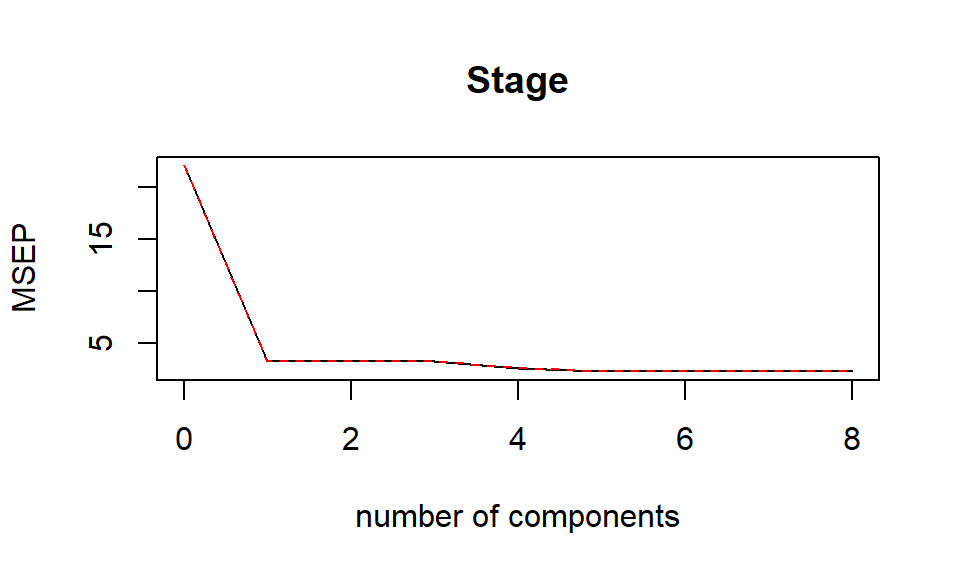

```r
validationplot(pcr.fit,val.type="MSEP")
```

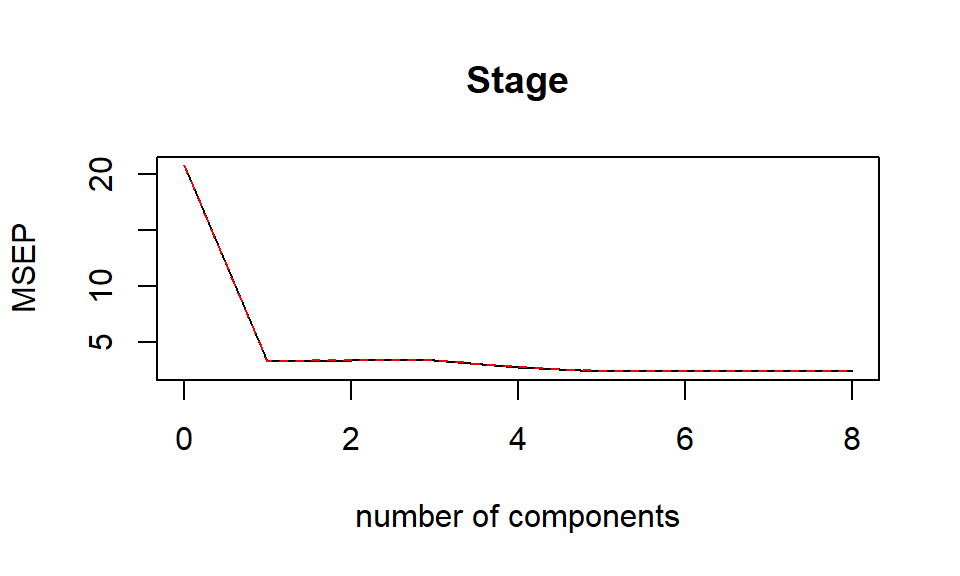

```r
set.seed(1)
pcr.fit=pcr(Stage~IO+BL+TL+Day+BLCM+Mass+RA+RB,data=Dev,scale=TRUE,validation="CV",subset=train)
validationplot(pcr.fit,val.type="MSEP")
```

```r
pcr.pred=predict (pcr.fit ,x[test ,],ncomp =5)
mean((pcr.pred-y.test)^2)
```

```
## [1] 4.997196
```

- Compute the MSE
- In addition, we now see that the cross-validated method prefers a model with 5 components

```r
pcr.fit=pcr(y~x,scale=TRUE,ncomp=5)
summary (pcr.fit)
```

```
## Data:    X dimension: 1420 8
##  Y dimension: 1420 1
## Fit method: svdpc
## Number of components considered: 5
## TRAINING: % variance explained
##    1 comps  2 comps  3 comps  4 comps  5 comps
## X    64.38    76.98    89.36    95.25    98.32
## y    84.98    84.98    84.98    87.97    89.52
```

# Partial Least Squares

- We can impkment the `plsr()` function also in the `pls` library

```r
set.seed(1)
pls.fit=plsr(Stage~., data=Dev ,subset=train,scale=TRUE, validation="CV")
summary (pls.fit)
```

[output not shown]

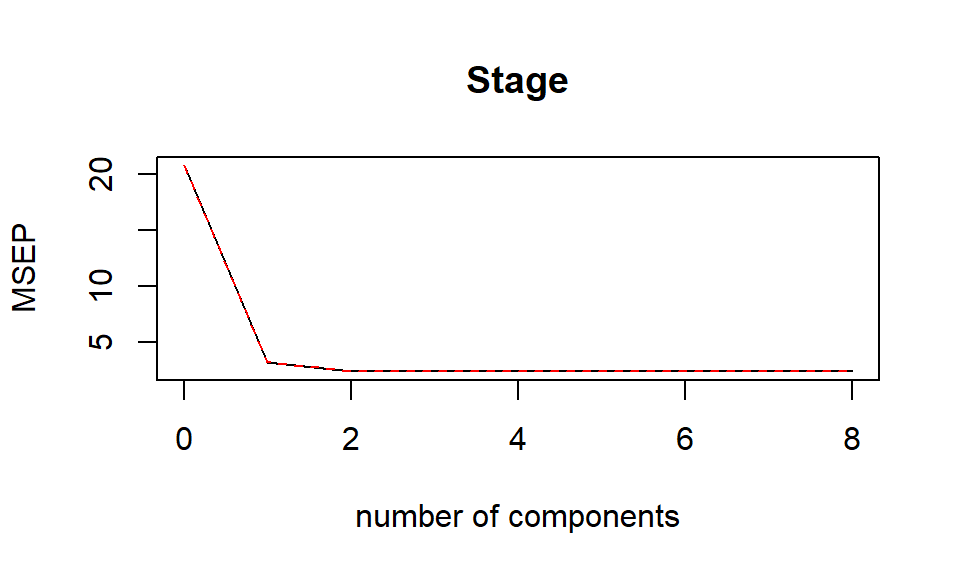

```r
validationplot(pls.fit ,val.type="MSEP")
```

```r
pls.pred=predict(pls.fit ,x[test ,],ncomp =3)
mean((pls.pred -y.test)^2)
```

```
## [1] 6.6992
```

```r
pls.fit=plsr(Stage~., data=Dev ,scale=TRUE,ncomp=3)
summary (pls.fit)
```

```
## Data:    X dimension: 1420 8
##  Y dimension: 1420 1
## Fit method: kernelpls
## Number of components considered: 3
## TRAINING: % variance explained
##        1 comps  2 comps  3 comps
## X        64.36    69.89    73.98
## Stage    85.65    89.29    89.59
```

# The Lasso Method

- We need to use the `glmnet()` function
- Make sure to switch `alpha=1` or you will preform a ridge regression * We can see from the coeffcient plot that depnding on the choice of tunning parameter some or most of the coefficents will be exatcly equal to zero
- now we preform cross validation and compute the associated MSE

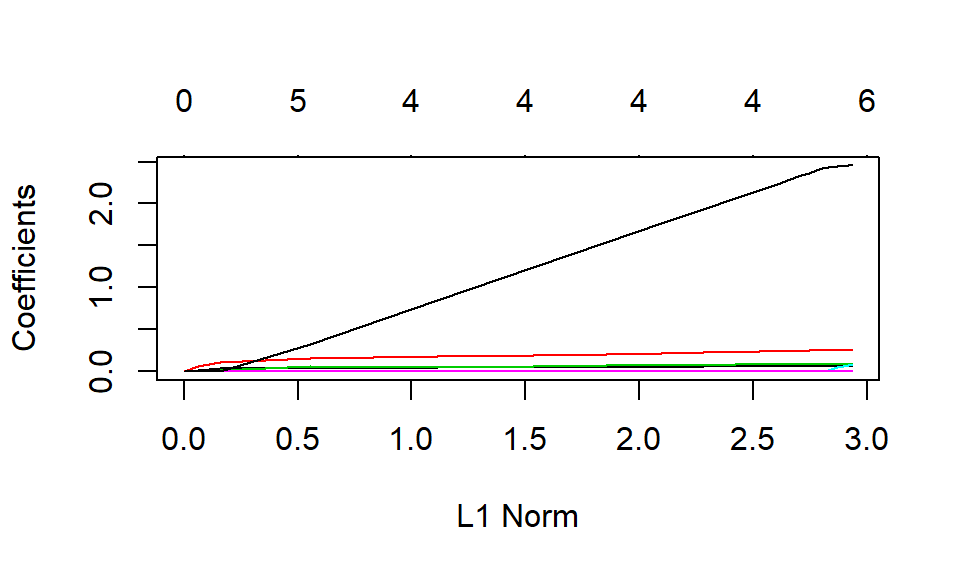

```r
grid<-10^seq(10,-2,length=100)
lasso.mod=glmnet(x[train,],y[train],alpha=1,lambda=grid)

plot(lasso.mod)
```

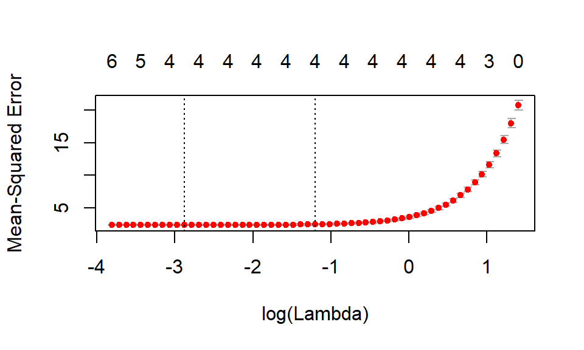

```r
 set.seed(1)
 cv.out=cv.glmnet(x[train,],y[train],alpha=1)
 plot(cv.out)
```

```r
 bestlam =cv.out$lambda.min
 lasso.pred=predict (lasso.mod ,s=bestlam ,newx=x[test,])

 mean((lasso.pred -y.test)^2)
```

```
## [1] 2.269133
```

- This MSE is lower than the previous methods achived

```r
out=glmnet(x,y,alpha=1,lambda=grid)

lasso.coef=predict (out ,type="coefficients",s=bestlam)[1:9,]

lasso.coef
```

```
## (Intercept)          IO          BL         Day          TL        BLCM
## 21.89043180  0.00000000  0.08575091  0.23336393  0.04051695  0.00000000
##          RA          RB        Mass
##  0.00000000  0.00000000  2.57039806
```

```r
lasso.coef[lasso.coef!=0]
```

```
## (Intercept)          BL         Day          TL        Mass
## 21.89043180  0.08575091  0.23336393  0.04051695  2.57039806
```

- Model selects only 4 predictor terms - IO is exlcuded as it dose not contribute enough to be signgifcant in the model

# Linear Model Assingment

1. *Using the `Dev.csv’ data sheet provided in part two - complete both best subset, forward, and backward model selection*
2. *Compare the terms selected between the diffreing methods*
3. *Complete a breif markdown file - reporting the AIC, Cp, and BIC values associated with the ‘best’ model from forward, backward and subset selection*

```r
S_set <- regsubsets(Stage ~ ., Dev, nvmax = 9)
```

```
## Reordering variables and trying again:
```

```r
results <- summary(S_set)
 results
```

```
## Subset selection object
## Call: regsubsets.formula(Stage ~ ., Dev, nvmax = 9)
## 8 Variables  (and intercept)
##      Forced in Forced out
## Day      FALSE      FALSE
## BL       FALSE      FALSE
## IO       FALSE      FALSE
## TL       FALSE      FALSE
## Mass     FALSE      FALSE
## RA       FALSE      FALSE
## RB       FALSE      FALSE
## BLCM     FALSE      FALSE
## 1 subsets of each size up to 7
## Selection Algorithm: exhaustive
##          Day BL  IO  TL  Mass BLCM RA  RB
## 1  ( 1 ) "*" " " " " " " " "  " "  " " " "
## 2  ( 1 ) "*" " " " " " " "*"  " "  " " " "
## 3  ( 1 ) "*" " " " " " " "*"  "*"  " " " "
## 4  ( 1 ) "*" " " " " "*" "*"  "*"  " " " "
## 5  ( 1 ) "*" "*" "*" "*" "*"  " "  " " " "
## 6  ( 1 ) "*" "*" "*" "*" "*"  " "  " " "*"
## 7  ( 1 ) "*" "*" "*" "*" "*"  " "  "*" "*"
```